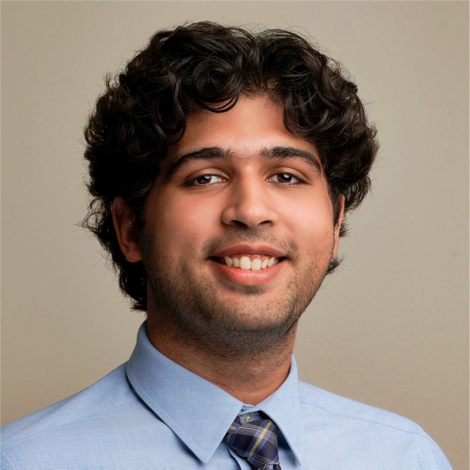

# Shaikh (Ibrahim) Noman

## Description

Hi, I’m Ibrahim. I’m a Statistics and Data Science undergraduate at UT Austin (minors in Computer Science and & Risk Management). I’ve worked as a Data Science Intern in the energy industry, building machine learning models, data pipelines, and decision-support tools used by business and operations teams.

My interests are in applied machine learning, LLM-powered applications, and data systems that drive real-world decisions across energy, finance, and consumer products.

## Education

**The University of Texas at Austin**  
B.S. Statistics and Data Science — May 2026  
Minors/Certificates: Computer Science & Risk Management

Relevant Coursework: Machine Learning, Databases, Data Engineering, Statistical Modeling, Data Visualization

## Experience

**Constellation Energy** — Data Science Intern  
- Improved workforce forecasting accuracy by 40% through scalable optimization models  
- Built analytics and dashboards used by management for staffing and productivity decisions  
- Designed ML evaluation frameworks to communicate precision–recall trade-offs to stakeholders

**Welligence Energy Analytics** — Data Science Intern  
- Built SQL + R ETL pipelines for 200+ countries using Docker  
- Improved geospatial data accuracy by identifying and resolving anomalies

**University of Texas at Austin** — Undergraduate Researcher (Bioinformatics)  
- Applied PCA, DAPC, and differential gene expression analysis across 100k+ genes  
- Built phylogenetic models for evolutionary trait inference

## Projects

[**Voice Emotion Detection App**](https://emotion-detect.streamlit.app/)  
- Built and deployed a real-time voice emotion detection app using PyTorch and Streamlit  
- Engineered a custom CNN with Librosa preprocessing on the RAVDESS dataset  
- Achieved 94% training and 77% validation accuracy across 8 emotion classes  
- Deployed publicly and version-controlled via GitHub

[**Studyable – ML-Powered Study Spot Recommender**](https://github.com/Ibrahim581/Data-Science-Projects/blob/main/2024/Studyable/Studyable%20-%20Longhorn%20Learners.pdf)  
- Led a cross-functional product team designing an ML-based recommendation system  
- Conducted 100+ customer interviews and market research  
- Won 1st place in a campus-wide pitch competition

## Interests

Applied ML systems • LLM applications • Data engineering • Sports analytics • Energy & finance

## Technical Skills

**Languages:** Python, R, SQL  
**Machine Learning:** Regression, Classification, Time Series Forecasting, NLP, Dimensionality Reduction  
**Deep Learning:** PyTorch, TensorFlow, Keras (CNNs, audio models)  
**Data & ML Tools:** Pandas, NumPy, Scikit-learn, Tidyverse, Librosa  
**LLMs & AI:** Transformers, Prompt Engineering, Model Evaluation (learning RAG & agents)  
**Data Engineering:** SQL pipelines, ETL, Docker, dbt  
**Cloud & Platforms:** AWS, GCP, Azure, Databricks, Snowflake  
**Visualization:** Power BI, Tableau, Shiny, Matplotlib

Last updated: December 18, 2025